# Part 3 Plotting the data

Now for the fun bit. We will learn how to plot our data.

Load up the data once more since this is a new session.

```r
library(tidyverse)
passengers<-read.csv("../data/train.csv")
```

## Plotting your data

To plot your data using `ggplot2`, you specify three things:

- Your data
- Your aesthetics (e.g. what’s on the x-axis)
- Your layers (e.g. barplot, scatterplot)

Also see the ggplot cheatsheet - ENGLISH - `cheatsheets/data-visualization-2.1.pdf` GERMAN - `cheatsheets/ggplot2-german_cheatsheet.pdf`

First you’ll plot a barplot of Sex to see how many males and females were recorded aboard the Titanic:

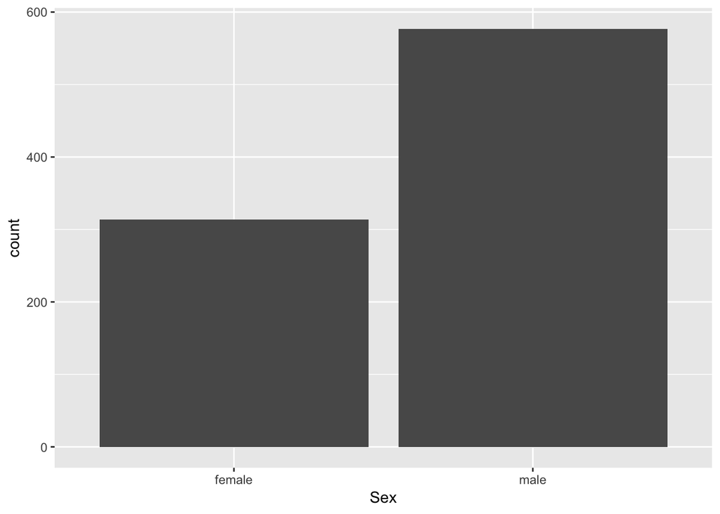

```r
# Plot barplot of passenger Sex
ggplot(passengers, aes(x = Sex)) +
  geom_bar()
```

**What can you see here?**

**Note:**

- the `aes()` function is really a way to map the `aes`thetics of the plot to the variables in the data. See [Modern Dive](http://moderndive.com/3-viz.html#grammarofgraphics) by Chester Ismay & Albert Y. Kim for more.

Now it’s time for some scatter plots. Is the Age of any given passenger correlated with the Fare that they paid?

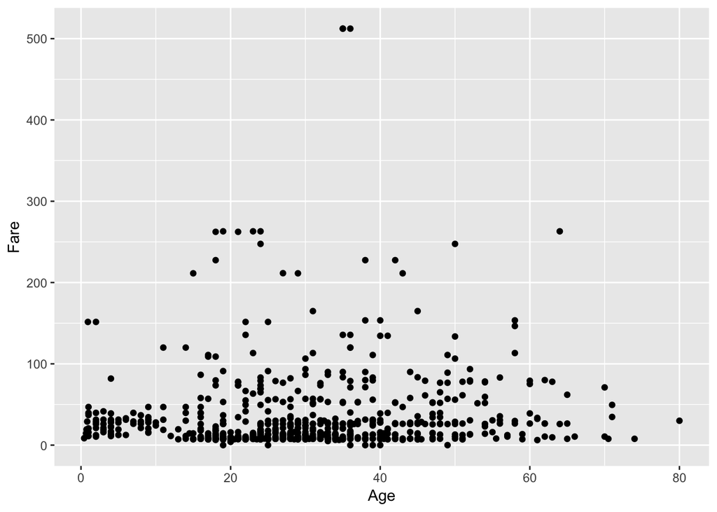

```r
# Scatter plot of Age vs Fare
ggplot(passengers, aes(x = Age, y = Fare)) +
  geom_point()
```

Let’s take the previous plot and color each point by Sex, to see any correlations between Sex, Age and Fare:

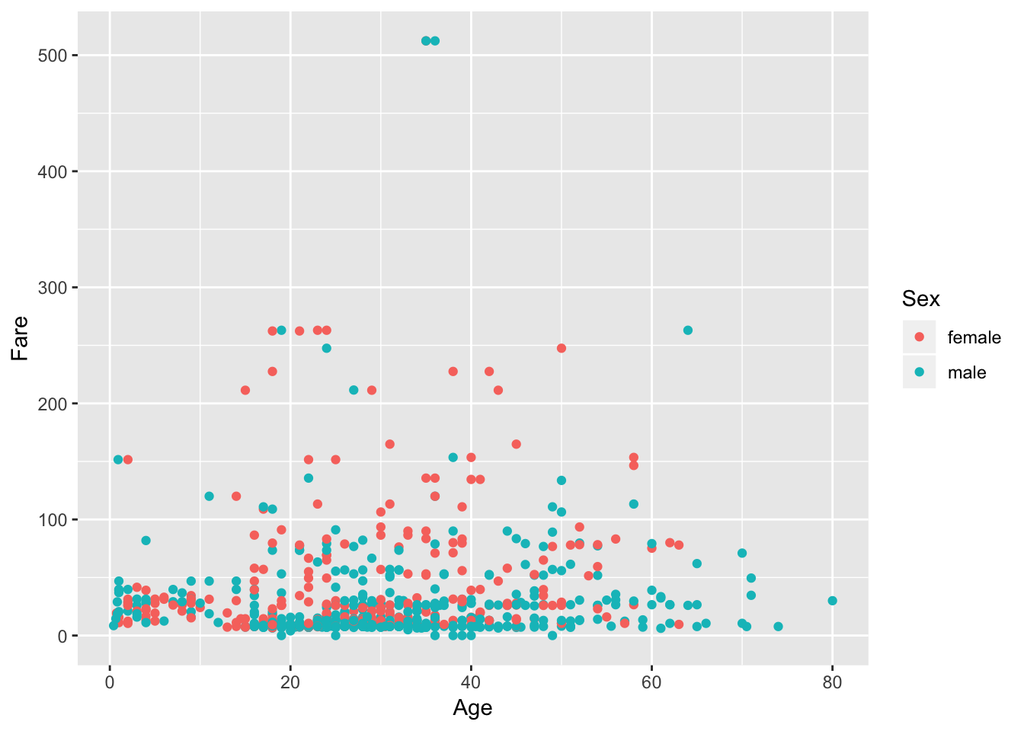

```r
# Scatter plot of Age vs Fare colored by Sex
ggplot(passengers %>% drop_na(), aes(x = Age, y = Fare, color = Sex)) +
  geom_point()
```

**What can you see here?**

Also note that we used a pipe in the data. So you can on the fly change your data and plot it.

## Lets play now with no zeros and ones we created towards the end of part 2

As zeroes and ones don’t often say a great deal, mutate the values of the “Survived” variable to strings “No” and “Yes” (and create new dataframe!):

```r
# Turn numerical values of Survived column to "No" & "Yes" (new dataframe)
passengers1 <- passengers %>%
  mutate(Survived = ifelse(Survived == 0, "No", "Yes"))
passengers1
```

| PassengerId | Survived | Pclass | Name | Sex | Age | SibSp | Parch | Ticket | Fare | Cabin | Embarked |
| --- | --- | --- | --- | --- | --- | --- | --- | --- | --- | --- | --- |
| 1 | No | 3 | Braund, Mr. Owen Harris | male | 22.00 | 1 | 0 | A/5 21171 | 7.2500 |  | S |
| 2 | Yes | 1 | Cumings, Mrs. John Bradley (Florence Briggs Thayer) | female | 38.00 | 1 | 0 | PC 17599 | 71.2833 | C85 | C |
| 3 | Yes | 3 | Heikkinen, Miss. Laina | female | 26.00 | 0 | 0 | STON/O2. 3101282 | 7.9250 |  | S |
| 4 | Yes | 1 | Futrelle, Mrs. Jacques Heath (Lily May Peel) | female | 35.00 | 1 | 0 | 113803 | 53.1000 | C123 | S |
| 5 | No | 3 | Allen, Mr. William Henry | male | 35.00 | 0 | 0 | 373450 | 8.0500 |  | S |
| 6 | No | 3 | Moran, Mr. James | male | NA | 0 | 0 | 330877 | 8.4583 |  | Q |
| 7 | No | 1 | McCarthy, Mr. Timothy J | male | 54.00 | 0 | 0 | 17463 | 51.8625 | E46 | S |
| 8 | No | 3 | Palsson, Master. Gosta Leonard | male | 2.00 | 3 | 1 | 349909 | 21.0750 |  | S |
| 9 | Yes | 3 | Johnson, Mrs. Oscar W (Elisabeth Vilhelmina Berg) | female | 27.00 | 0 | 2 | 347742 | 11.1333 |  | S |
| 10 | Yes | 2 | Nasser, Mrs. Nicholas (Adele Achem) | female | 14.00 | 1 | 0 | 237736 | 30.0708 |  | C |

[output cut: 881 more lines]

## Facetting your graph

Visualizing three variables on one plot is pretty cool, but what if wanted to throw the Survived variable into the mix to see if there are any apparent trends?

Faceting is a way to produce multiple plots simultaneously:

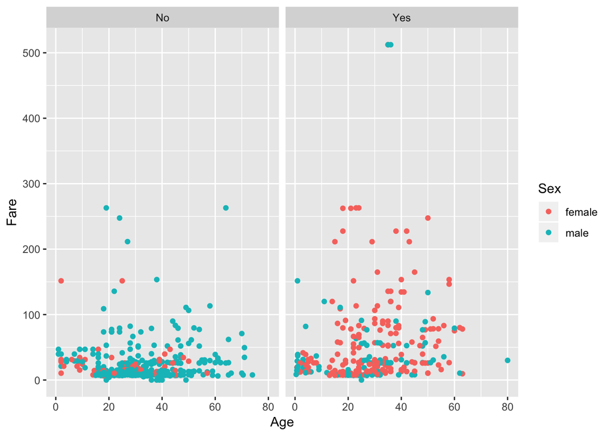

```r
# Scatter plot of Age vs Fare colored by Sex faceted by Survived
ggplot(passengers1, aes(x = Age, y = Fare, color = Sex)) +
  geom_point() +
  facet_grid(~Survived)
```

**What can you see here?**

Now let’s redo our bar plot of passenger “Sex” and this time fill our bars according to “Survived”:

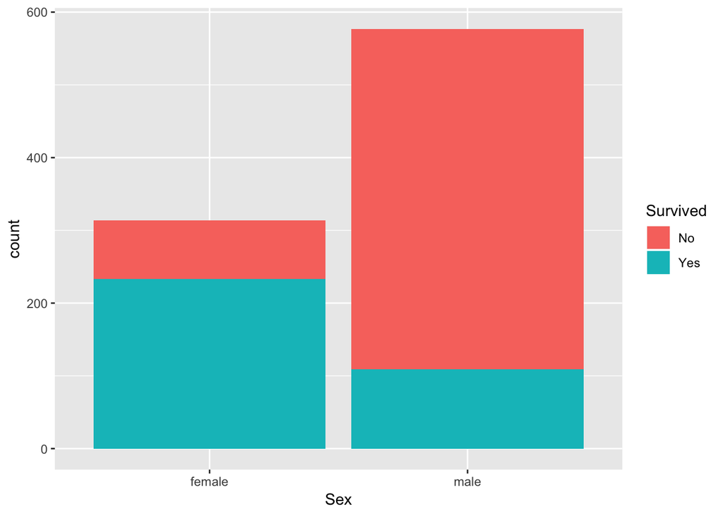

```r
# Plot barplot of passenger Sex & fill according to Survival
ggplot(passengers1, aes(x = Sex, fill = Survived)) +
  geom_bar()
```

**What can you see here?**

## Plot axis modifications

Say now you want to modify the axis of the graph above

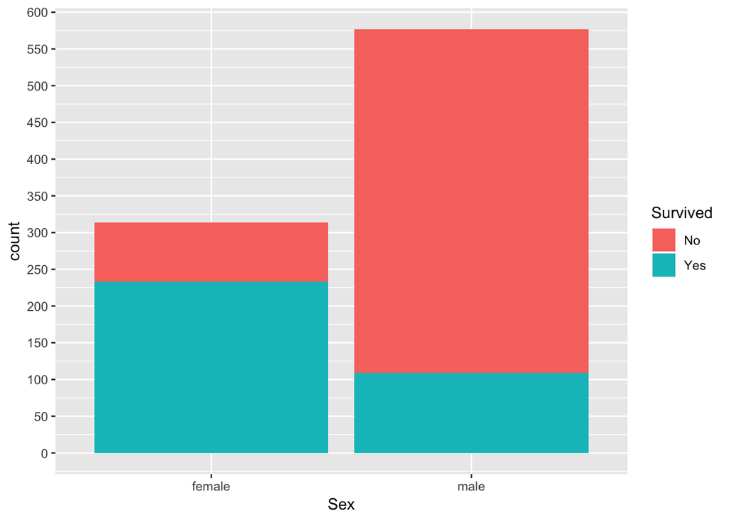

```r
# Plot barplot of passenger Sex & fill according to Survival
# Use scale_y_continuous to modify axis breaks
ggplot(passengers1, aes(x = Sex, fill = Survived)) +
  geom_bar()+
  scale_y_continuous(breaks=seq(0,1000,50))
```

What we have done there is changes the scale of the y axis.

We used `scale_y_continuous(breaks=seq(0,1000,50))` which essentially says breaks are sequentially added between 0 to 1000 at intervals of 50 units.

**CHANGE AXIS TITLES**

Often one wants to change axis titles and this is an easy step. Below is the R code for doing so.

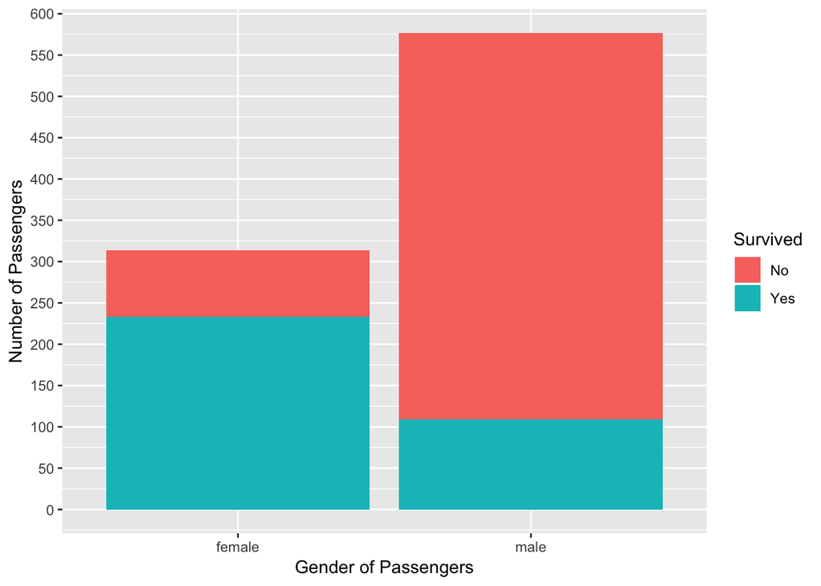

```r
# Change x and y labels of the plot
ggplot(passengers1, aes(x = Sex, fill = Survived)) +
  geom_bar()+
  scale_y_continuous(breaks=seq(0,1000,50))+
  xlab("Gender of Passengers")+
  ylab("Number of Passengers")
```

`xlab` and `ylab` can alter the column headings to more meaningful names.

**How do we change the theme of the graph?**

That grey backdrop is very ugly. Lets change that.

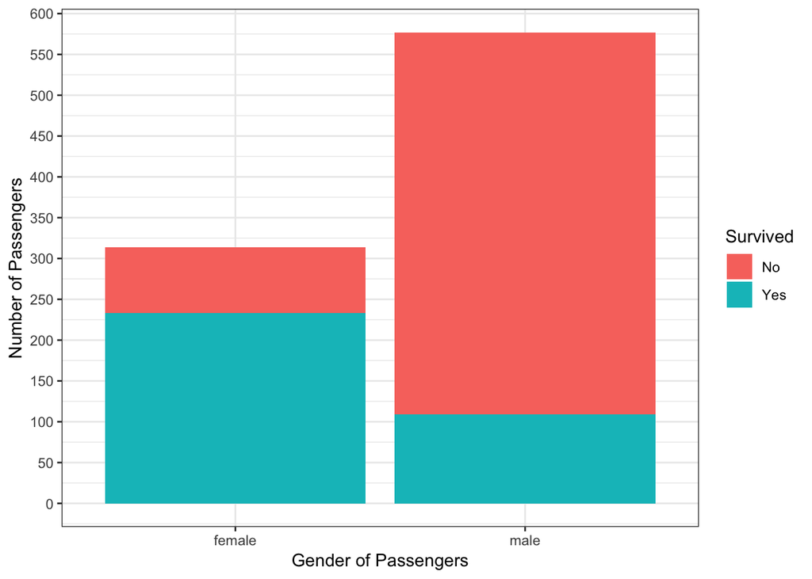

```r
# Change to a theme which gives a clear background
ggplot(passengers1, aes(x = Sex, fill = Survived)) +
  geom_bar()+
  scale_y_continuous(breaks=seq(0,1000,50))+
  xlab("Gender of Passengers")+
  ylab("Number of Passengers")+
  theme_bw()
```

**But the lines too are very annoying. Can we get rid of them??** yes ggplot has you covered.

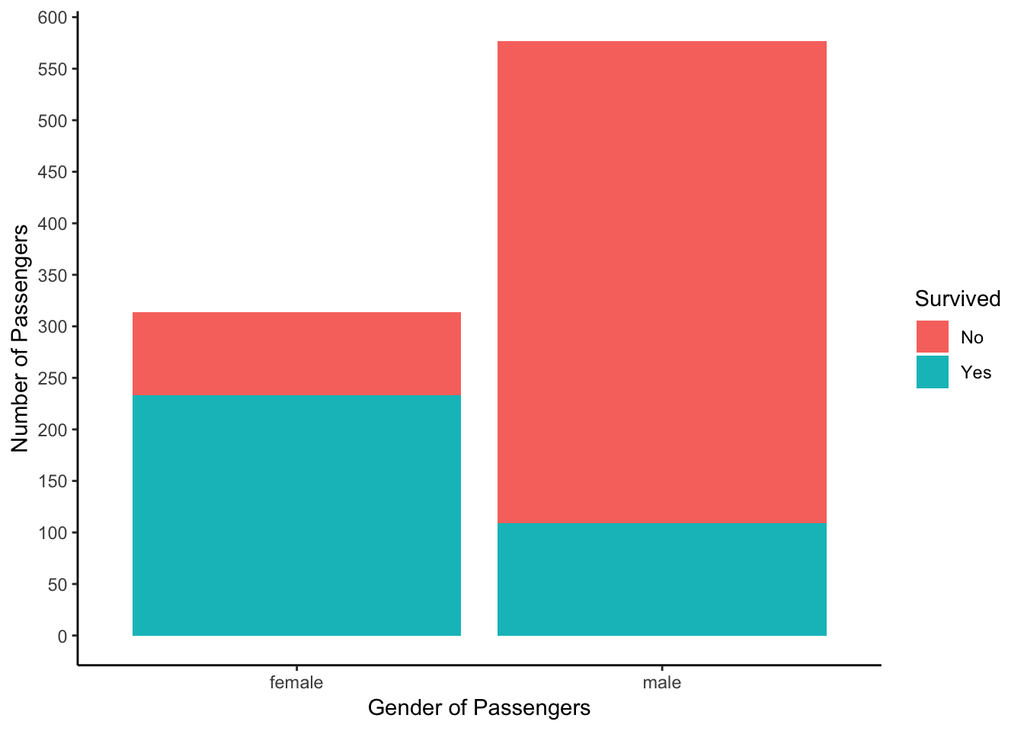

```r
# Have a clear background for the graph with theme_classic
ggplot(passengers1, aes(x = Sex, fill = Survived)) +
  geom_bar()+
  scale_y_continuous(breaks=seq(0,1000,50))+
  xlab("Gender of Passengers")+
  ylab("Number of Passengers")+
  theme_classic()
```

**Why are my bars floating can they sit on the x axis**

you asked and ggplot delivered!

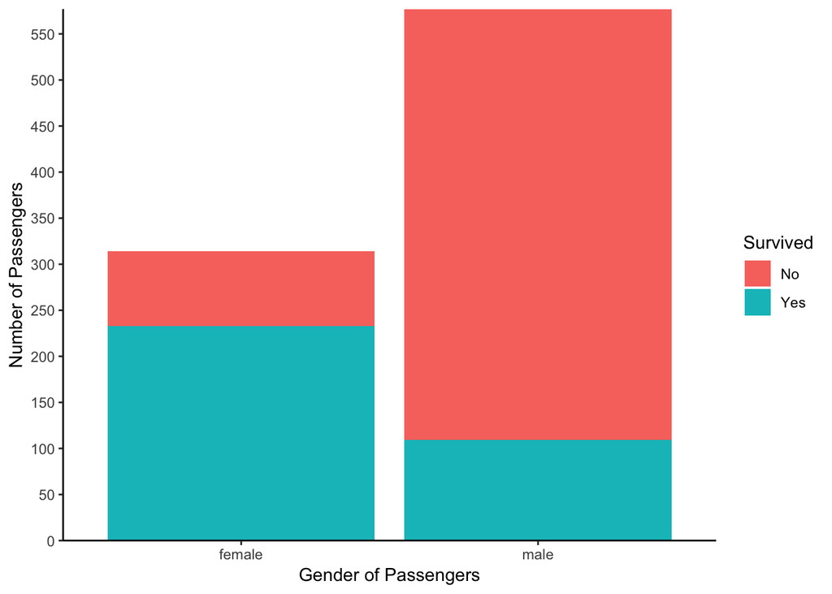

```r
#Make the bars touch the x axis
ggplot(passengers1, aes(x = Sex, fill = Survived)) +
  geom_bar()+
  scale_y_continuous(breaks=seq(0,1000,50), expand = c(0,0))+
  xlab("Gender of Passengers")+
  ylab("Number of Passengers")+
  theme_classic()
```

**Identify what changed?**

**But can you add a black border to the bars? That would look good.**

Yes why not. Just because you asked nicely.

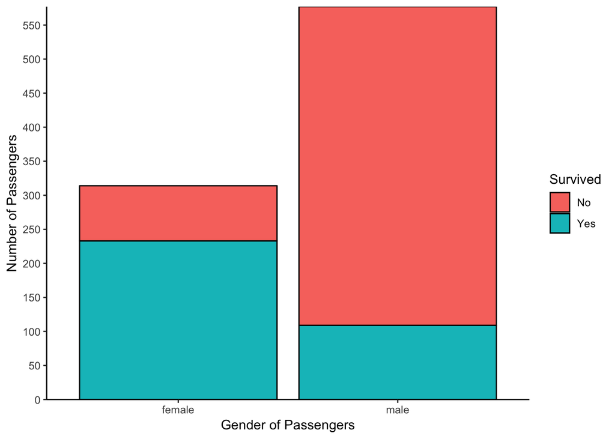

```r
#Give a black border to the bars
ggplot(passengers1, aes(x = Sex, fill = Survived)) +
  geom_bar(color = "black")+
  scale_y_continuous(breaks=seq(0,1000,50), expand = c(0,0))+
  xlab("Gender of Passengers")+
  ylab("Number of Passengers")+
  theme_classic()
```

## These are not the only types of plots. Lets look at the cheatsheet and make some plots.

May be each person could make a plot with the data and show us the graph.

## Saving your graphs so you can use them for papers and presentations.

Now that you have created so many graphs its time to save them. Currently these graphs exists as R code and not object. So lets make an R object of the graphs.

```r
#Save graph: Save to an R object
plot <- ggplot(passengers1, aes(x = Sex, fill = Survived)) +
          geom_bar(color = "black")+
          scale_y_continuous(breaks=seq(0,1000,50), expand = c(0,0))+
          xlab("Gender of Passengers")+
          ylab("Number of Passengers")+
          theme_classic()
```

See what happens when you call this R object.

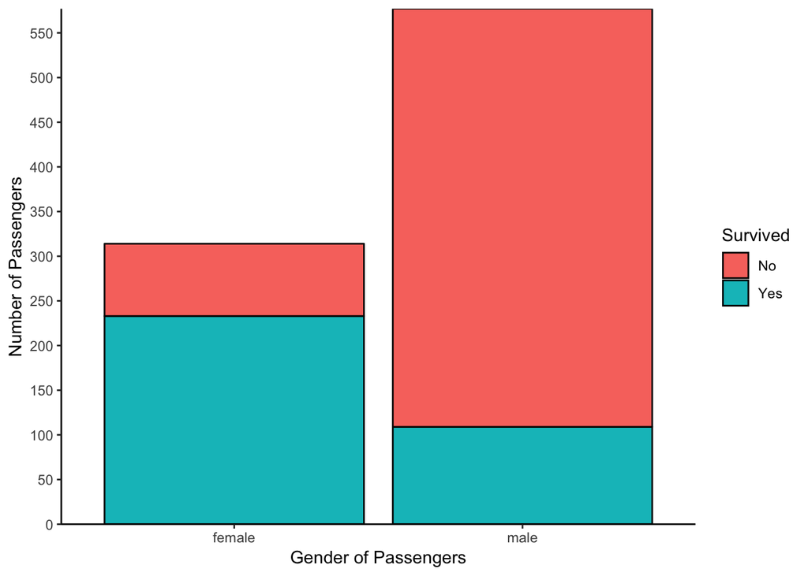

```r
#Call the object plot
plot
```

Now lets save the object plot.

```r
#Saving the figure in object plot
ggsave("../Output/plot.pdf", plot = plot, scale = 1, width = 10, height = 10, units = c("cm"), dpi=600)
```

# Assembly of multiple plots in a single figure.

Two packages are available for doing this task.

1. [Patchwork](https://patchwork.data-imaginist.com/index.html)
2. [Cowplot](https://wilkelab.org/cowplot/index.html)